# Causal DAG

Julian Frattini

2025-02-10

This notebook visualizes the causal assumptions about the collected data in the RQ4TLR study.

## Variables

In the `vars` data frame, we capture all variables that we can involve in our observational study. Immeasurable variables are not listed here, but variables that we excluded due to their lack of distribution are listed below.

```r
vars = data.frame(varname = character(), # short variable name (e.g., perf)
                  fullname = character(), # full, expressive name of the variable (e.g., TLR performance)
                  x = double(), y = double(), # x and y coordinates of this variable in the figure
                  stringsAsFactors=FALSE)
```

Each variable is associated to a short variable name, its full name, and coordinates.

```r
vars <- vars %>% add_row(varname = "perf", fullname = "TLR Performance", x = 2, y = 0)

vars <- vars %>% add_row(varname = "dataset", fullname = "Data Set", x = -1, y = 0)
vars <- vars %>% add_row(varname = "sencomplexity", fullname = "Maximum Step Complexity", x = 0, y = 0.5)
vars <- vars %>% add_row(varname = "maxsteplength", fullname = "Maximum Step Length", x = 0, y = 0.3)
vars <- vars %>% add_row(varname = "size", fullname = "Use Case Size", x = 0, y = 0.1)
vars <- vars %>% add_row(varname = "inconsistentloa", fullname = "Inconsistent Level of Abstraction", x = 0, y = -0.1)
vars <- vars %>% add_row(varname = "uidesign", fullname = "Contains UI Design Details", x = 0, y = -0.2)
vars <- vars %>% add_row(varname = "clarification", fullname = "contains clarification", x = 0, y = -0.3)
vars <- vars %>% add_row(varname = "alternative", fullname = "Contains Alternative", x = 0, y = -0.4)
vars <- vars %>% add_row(varname = "coherence", fullname = "Level of Coherence", x = 0, y = -0.5)


vars <- vars %>% add_row(varname = "happy", fullname = "Happy Use Case", x = 0, y = -0.6)
vars <- vars %>% add_row(varname = "lostfr", fullname = "Mislocated Functional Requirements", x = 0, y = -0.7)
vars <- vars %>% add_row(varname = "anaphora", fullname = "Anaphora", x = 0, y = -0.8)
vars <- vars %>% add_row(varname = "nonnounstart", fullname = "Non-noun Start", x = 0.4, y = -0.9)
vars <- vars %>% add_row(varname = "passive", fullname = "Passive Voice", x = 0, y = -1)
vars <- vars %>% add_row(varname = "negation", fullname = "Negation", x = 0, y = -1.1)
vars <- vars %>% add_row(varname = "outlinks", fullname = "Scatter", x = 0, y = -1.2)
vars <- vars %>% add_row(varname = "maxinlinks", fullname = "Tangle", x = 0, y = -1.3)
```

The following variables were ignored due to their imbalanced distribution in the data set:

- *Meaningless Actors* (`meanuc`): the variable perfectly correlates with the `dataset` variable and, therefore, bears no information
- *Functional Duplication* (`duplicate`): the data set did not contain a single instance of functional duplication
- *Meaningless Use Case* (`meanuc`): the data set contained too few instances of meaningless use cases
- *Use Case Naming Problems* (`nameproblem`): there are only a few instances in the iTrust data set with naming problems
- *Inappropriate Scope* (`scope`): there are hardly any instances of scoping problems encountered in the data set
- *Incoherent Test Order* (`textorder`): there are only a few instances in the iTrust data set with an incoherent text order
- *Inputs or Outputs not quantified* (`iounquantified`): there are only a few instances in the etour data set where the inputs/outputs are not quantified
- *Contains Actor-Actor Interaction* (`actoractor`): there are hardly any instances of actor-actor interactions encountered in the data set
- *Contains justifications* (`justification`): the data set did not contain a single justification
- *Coordination Ambiguity* (`coordambiguity`): there are only very few instances of coordination ambiguity at all
- *Optional* (`optional`): there are too few instances of optional parts in the data set
- *Incomplete Comparisons*: there are too few instances of incomplete comparisons and they only occur in the eTour data set

The data frame allows extracting named lists from the data frame (one for the full name, one for the x and one for the y positions).

```r
map.name <- setNames(vars$fullname, vars$varname)
map.x <- setNames(vars$x, vars$varname)
map.y <- setNames(vars$y, vars$varname)
```

## Directed Acyclic Graph

With the variables defined, we can specify and visualize the causal directed, acyclic graph (DAG).

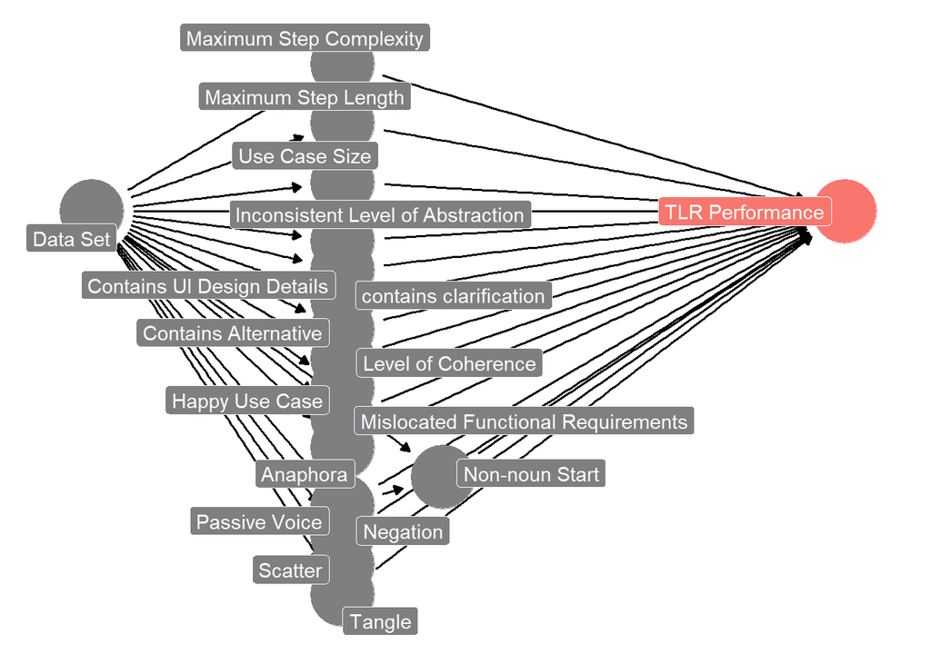

```r
dag <- dagify(
  perf  ~ dataset + sencomplexity + maxsteplength + size + inconsistentloa + uidesign + clarification + alternative + coherence + happy + lostfr + anaphora + nonnounstart + passive + negation + outlinks + maxinlinks,

  size ~ dataset,
  maxsteplength ~ dataset,
  sencomplexity ~ dataset + maxsteplength,
  inconsistentloa ~ dataset,
  uidesign ~ dataset,
  clarification ~ dataset,
  alternative ~ dataset,
  coherence ~ dataset,
  happy ~ dataset,
  lostfr ~ dataset,
  anaphora ~ dataset,
  nonnounstart ~ dataset + passive,
  passive ~ dataset,
  negation ~ dataset,
  outlinks ~ dataset,
  maxinlinks ~ dataset,

  outcome = "perf", # determine TLR performance as the response variable
  labels = map.name,
  coords = list(x = map.x, y = map.y)
)

ggdag_status(dag, use_labels = "label", text = FALSE) +
  guides(fill = "none", color = "none") +
  theme_dag()
```

This DAG represents the foundation of our causal assumptions. Based on our domain knowledge and prior literature, we expect some sort of effect of these variables on the performance of traceability link recovery.